# Recovering missing test data points

Compiled: December 03, 2021

### Introduction

Generalised Canonical Procrustes (gcproc) can recover missing values in a dataset via a prediction or imputation step, depending on the missingness of the data. Recovery begins by projecting the features of the data into a reduced dimensional subspace: encoding to improve information quality. When both the predictor (y) and feature (x) variables are transformed via the encoding projection learned in gcproc, a machine learning model is used to find an estimate of the predictor. The key step in this process is learning a set of parameters via gcproc that encode the features to enrich the information quality before input into the model for regression.

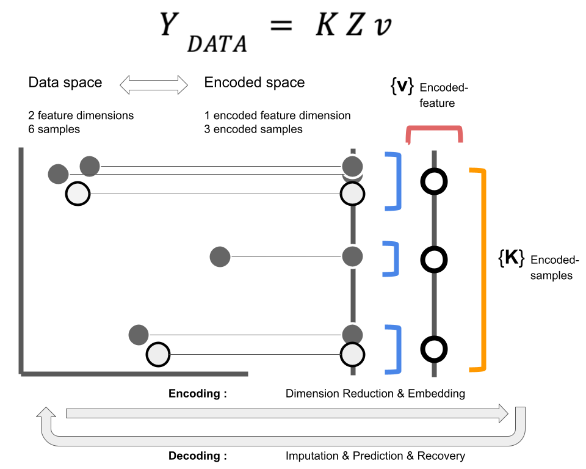

### Step 0 - Prepare libraries

```
## Package 'mclust' version 5.4.8
```

### Step 1 - Initialise config

```
## $method
## [1] "gcproc"
##
## $init
## [1] "random" "svd"
##
## $identify
## [1] FALSE
##
## $i_dim
## [1] 30
##
## $j_dim
## [1] 30
##
## $min_iter
## [1] 2
##
## $max_iter
## [1] 350
##
## $n_decode
## [1] 30
##
## $seed
## [1] 1
##
## $tol
## [1] 1
##
## $verbose
## [1] TRUE
```

### Step 2 - Prepare data

```
## pdfCluster 1.0-3
```

### Step 3 - Run gcproc, glmnet and linear model on test datasets

Four datasets are used in this regression to recover missing values. The most variable feature is listed as the variable to be predicted, while all other variables are listed as the covariates.

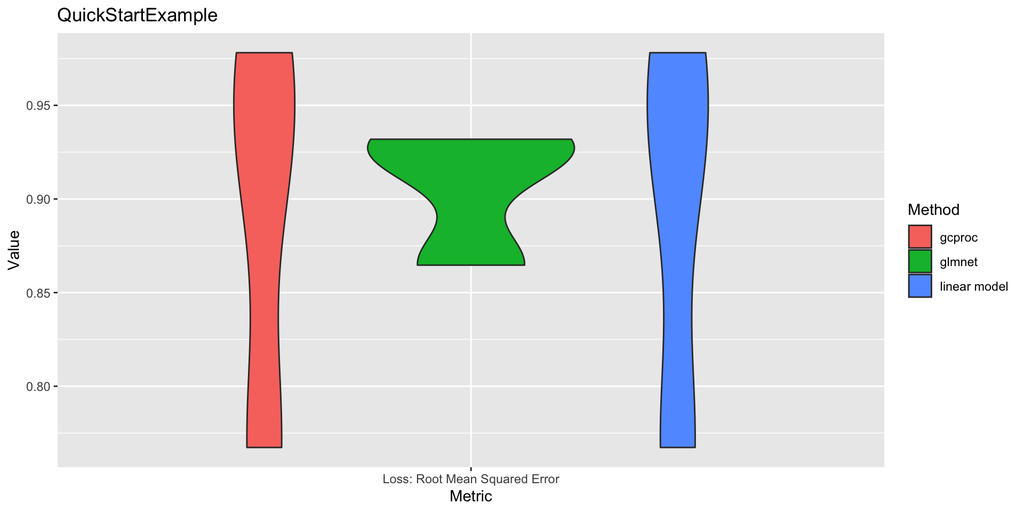

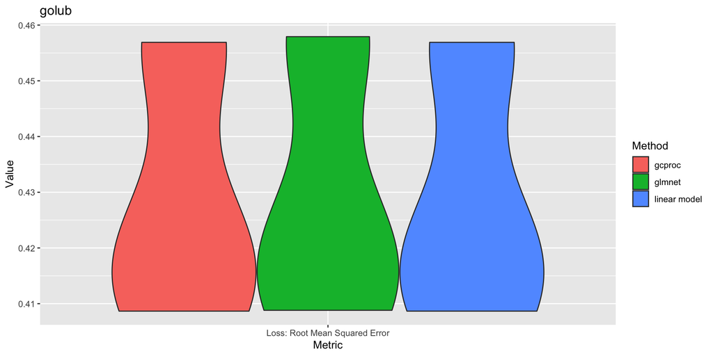

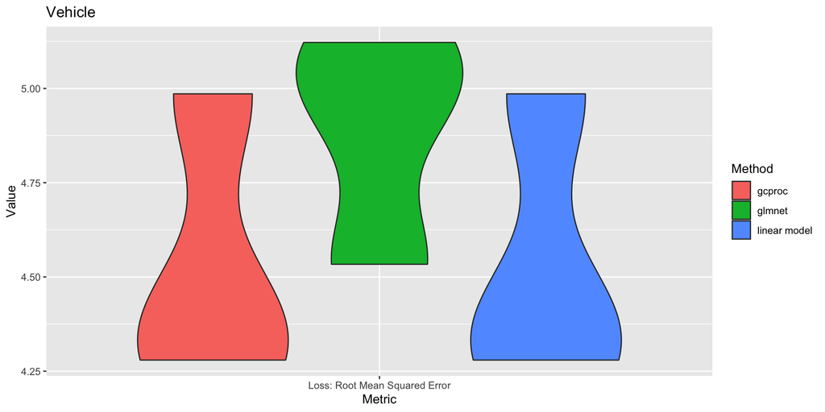

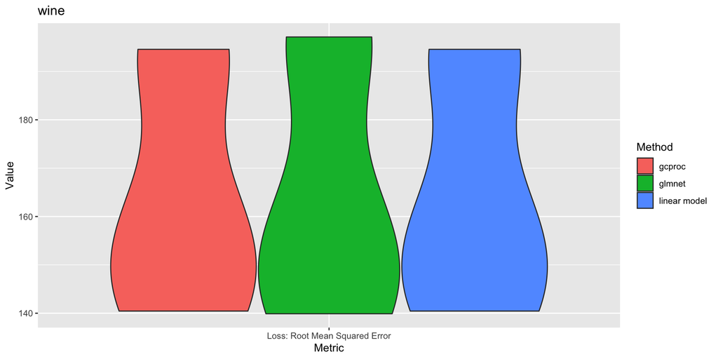

### Step 4 - Run gcproc and mice on various datasets with missigness via ampute

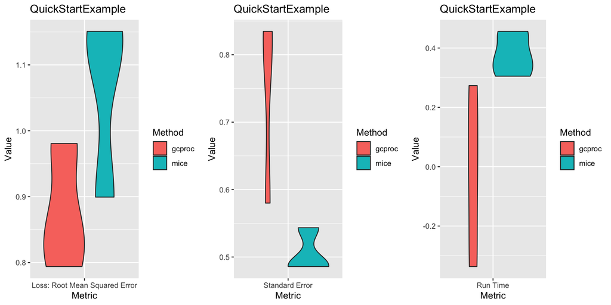

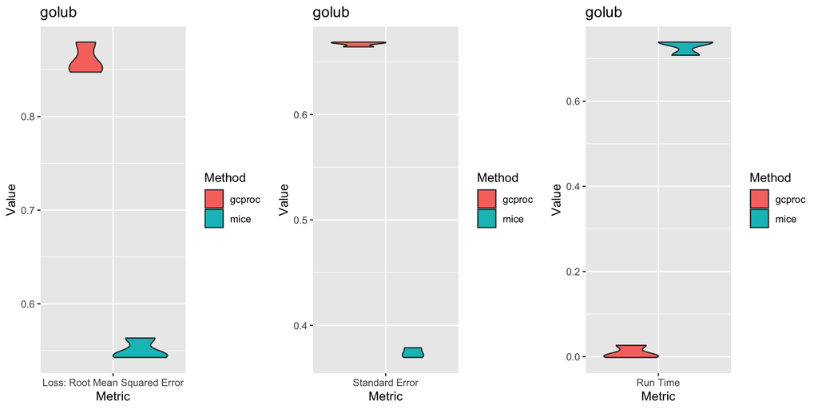

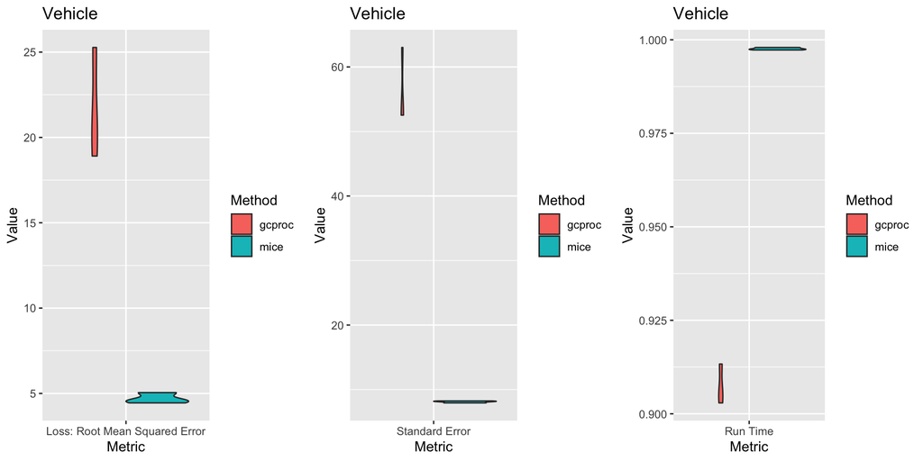

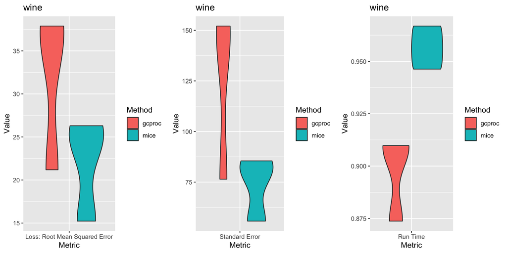